# Results and comments

Medical Expenditure Panel Survey (MEPS) data describes medical patients and their cost of health care. Data is composed of the patient’s demographic (age, race, gender), social-economic (education, income, insurance) and medical information (diagnosed diseases, symptoms, health status based on self-filled survey). There are 44 variables. The predictive variable is called HEALTHEXP (describes healthcare expenditure).

Due to the long tail of the predictive variable, HEALTHEXP was transformed with a logarithm of a base 3. Boxpolots below show the predictive variable before and after the transformation. Data is composed of 8 numerical variables and 35 categorical variables.

Two models were trained (XGB and linear).

**XGB model** was trained with pipeline. The pipeline standard scaled the numerical variables and one hot encoded the categorical variables. Model results on test set:

- r2: 0.372
- rmse: 2.174
- mae: 1.613

ALE and PDP results:

- *AGE31X*: this variable describes the age of the patient. There is visible upward trend. Trend is not linear and there are some disorder. It drops around age 27, 49. There is also soaring change around age 50 and 65. This description is intuitively reasonable since people’s health gets worse with age. The drops and increase could be caused by screening which are often set to be made at certain age.
- *K6SUM42*: this variable describes overall ratings of feelings. The predictions increase as the rating growth to 2 than it is rather stable with few small exceptions (drops around 11 and than growth back at 14). The low value could more meaningfully change the outcome of the prediction.
- *POVCAT15*: the variable describes the poverty status of the patient. The lower value than the poorer patient. The trend is almost linear and the more wealthy patient is the more he/she spends on healthcare.
- *RTHLTH31*: the variable describes perceived health status. 5 stands for poor health status and 1 means excellent. The health expenditure increases as the status value increases. There is small decrease in a prediction after passing value 4 which could be caused by people tendency to exaggerating.
- *DIABDX*: the variable describes the diabetes diagnosis. -1 means inapplicable, 1 positive, 2 negative. The cots predictions increases with the positive diagnosis. There is small difference between -1 and 2 effect on the prediction.
- *INSCOV15*: the variable describes patient’s insurance coverage (1 private, 2 public, 3 none). Patient with a insurance (private or public) has higher prediction than the patient without the insurance. The prediction for a patient with a private insurance is higher about 3 to the power of 0.2 for both plots.
- *PHQ242*: this variable describes the ratings of feelings. The model predictions looks like is almost the same for all of the values. The difference between the highest and the lowest prediction is between 3 to the power of 0.1 times.
- *PREGNT31*: the variable describes the pregnancy diagnosis. -1 means inapplicable, 1 positive, 2 negative. The pregnancy increases the prediction by around 9 times.

**Linear model** was trained and tested on the same data as XGB model. The model results:

- r2: 0.315
- rmse: 2.271
- mae: 1.711

ALE and PDP results:

- **AGE31X**: strictly increasing. Since it is linear model there is no possiblity for sudden drops and increase as in XGB model.
- **K6SUM42**: also strictly increasing (pdp avg from 5.3 to 6.6, ale avg from 5.8 to 7.1) while in XGB model the prediction was more stable after the value 2.
- **POVCAT15**: as in XGB model the prediction increases.
- **RTHLTH31**: as in XGB model the costs predictions increase, but there is no decrease after the value 4.
- **DIABDX**: inapplicable value seams to carry the most value and increase the prediction the most (as opposite to XGB model).
- **INSCOV15**: similar results as in XGB model, but there is a bigger difference in the cost prediction between public and private insured patient.
- **PHQ242**: also similar result as in XGB model, the value of PHQ242 does not change the predictions value much.
- **PREGNT31**: the negative diagnosis of pregnancy actually increases the cost the most. This is completely different than in XGB model.

```python
import numpy as np
import matplotlib.pyplot as plt
import pandas as pd
from sklearn.metrics import mean_squared_error, r2_score, mean_absolute_error
import xgboost as xgb
from sklearn.linear_model import Ridge
from sklearn.preprocessing import OneHotEncoder
from sklearn.preprocessing import MinMaxScaler
import dalex as dx
from sklearn.preprocessing import StandardScaler, OneHotEncoder
from sklearn.impute import SimpleImputer
from sklearn.pipeline import Pipeline
from sklearn.compose import ColumnTransformer
```

## Preparing data (logarithmic transformation of explainable variable, division into training and test data set)

```python
# Loading data and data processing
df_train = pd.read_csv("MEPS_data_preprocessed_train.csv")
df_test = pd.read_csv("MEPS_data_preprocessed_test.csv")

# droping columns
df_train.drop(columns = ['PANEL', 'PERSONWT'], inplace=True)
df_test.drop(columns = ['PANEL', 'PERSONWT'], inplace=True)

df_train.head(5)
```

|  | REGION | AGE31X | GENDER | RACE3 | MARRY31X | EDRECODE | FTSTU31X | ACTDTY31 | HONRDC31 | RTHLTH31 | ... | ADSMOK42 | PCS42 | MCS42 | K6SUM42 | PHQ242 | EMPST31 | POVCAT15 | INSCOV15 | INCOME_M | HEALTHEXP |
| --- | --- | --- | --- | --- | --- | --- | --- | --- | --- | --- | --- | --- | --- | --- | --- | --- | --- | --- | --- | --- | --- |
| 0 | 1 | 49 | 1.0 | 0.0 | 1 | 16 | -1 | 2 | 2 | 1 | ... | 1 | 51.29 | 59.04 | 1 | 0 | 1 | 3 | 1 | 8400.0 | 1462 |
| 1 | 3 | 43 | 1.0 | 0.0 | 4 | 14 | -1 | 2 | 2 | 5 | ... | 1 | 19.36 | 31.90 | 14 | 2 | 4 | 1 | 2 | 0.0 | 14121 |
| 2 | 1 | 75 | 1.0 | 0.0 | 1 | 13 | -1 | 4 | 2 | 4 | ... | 2 | 25.23 | 45.46 | 6 | 2 | 4 | 4 | 1 | 22619.0 | 58507 |
| 3 | 1 | 26 | 0.0 | 1.0 | 5 | 13 | -1 | 2 | 2 | 1 | ... | 2 | 49.13 | 63.97 | 4 | 0 | 1 | 3 | 1 | 20000.0 | 0 |
| 4 | 3 | 43 | 1.0 | 0.0 | 9 | 14 | -1 | 2 | 2 | 1 | ... | -1 | -1.00 | -1.00 | -1 | -1 | 1 | 4 | 1 | 58000.0 | 53936 |

5 rows × 44 columns

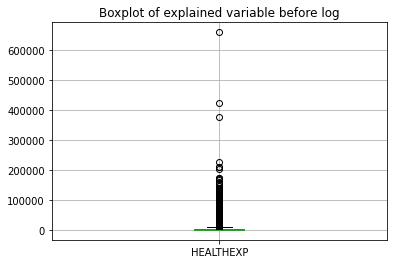

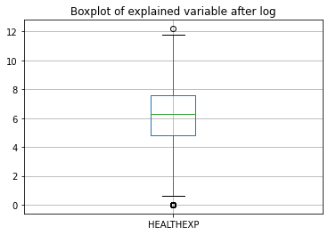

```python
# Y variable
df_train.boxplot(column="HEALTHEXP", return_type='axes')
plt.title( "Boxplot of explained variable before log" )
plt.suptitle('')
plt.show()


# Logarithmic transforamtion of healthexpenses
val_train = df_train['HEALTHEXP'].values
df_train['HEALTHEXP'] = np.array([0 if v == 0 else np.log(v) / np.log(3) for v in val_train])
val_test = df_test['HEALTHEXP'].values
df_test['HEALTHEXP'] = np.array([0 if v == 0 else np.log(v) / np.log(3) for v in val_test])

df_train.boxplot(column="HEALTHEXP", return_type='axes')
plt.title( "Boxplot of explained variable after log" )
plt.suptitle('')
plt.show()
```

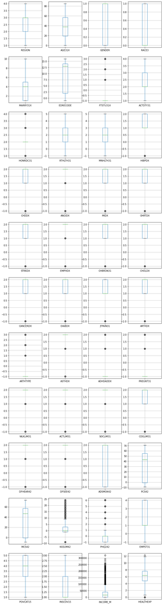

```python
fig, axes = plt.subplots(11, 4, figsize = (12, 48))

i = 0
for triaxis in axes:
    for axis in triaxis:
        df_train.boxplot(column = df_train.columns[i], ax = axis)
        i = i+1

plt.show()
```

```python
num_inx = df_train.nunique()[df_train.nunique() > 10 ].index.tolist()

inx_to_minmax_scale = ['RTHLTH31', 'MNHLTH31', 'POVCAT15']

num_inx.extend(inx_to_minmax_scale)
num_inx.remove('HEALTHEXP')
print(f"Numerical variables ({len(num_inx)}): {num_inx}")
```

```
Numerical variables (8): ['AGE31X', 'PCS42', 'MCS42', 'K6SUM42', 'INCOME_M', 'RTHLTH31', 'MNHLTH31', 'POVCAT15']
```

```python
cat_inx = df_train.nunique()[df_train.nunique() <= 10 ].index.tolist()
cat_inx = [x for x in cat_inx if x not in num_inx]

for cat in cat_inx:
    df_train[cat] = df_train[cat].astype('str')
    df_test[cat] = df_test[cat].astype('str')

print(f"Categorical variables ({len(cat_inx)}): {cat_inx}")
```

[output not shown]

```python
x_train = df_train.drop(["HEALTHEXP"], axis = 1)
y_train = df_train["HEALTHEXP"]
x_test = df_test.drop(["HEALTHEXP"], axis = 1)
y_test = df_test["HEALTHEXP"]
```

```python
# Function to score model (r^2, rmse, mae)
def get_model_results(model_name: str, pred_train, y_train, pred_test, y_test, print_res):
    rmse_train = np.sqrt(mean_squared_error(y_train, pred_train))
    r_2_train = r2_score(y_train, pred_train)
    rmse_test = np.sqrt(mean_squared_error(y_test, pred_test))
    r_2_test = r2_score(y_test, pred_test)
    mae_test = mean_absolute_error(y_test, pred_test)
    mae_train = mean_absolute_error(y_train, pred_train)

    if print_res:
        print(f"{model_name} results:")
        print(f"training rmse: {rmse_train}\ntraining r2: {r_2_train}\ntraining mae: {mae_train}")
        print(f"test rmse: {rmse_test}\ntest r2: {r_2_test}\ntest mae: {mae_test}\n")

    return [rmse_train, rmse_test,  r_2_train, r_2_test,  mae_train,  mae_test]
```

```python
numerical_transformer = Pipeline(
    steps=[
        ('scaler', StandardScaler())
    ]
)

categorical_transformer = Pipeline(
    steps=[
        ('onehot', OneHotEncoder(handle_unknown='ignore'))
    ]
)

preprocessor = ColumnTransformer(
    transformers=[
        ('num', numerical_transformer, num_inx),
        ('cat', categorical_transformer, cat_inx)
    ]
)
```

## XGB model

```python
d = 6
n = 60
feature_names = list(x_train)
xgb_reg = xgb.XGBRegressor(objective ='reg:squarederror',
                          colsample_bytree = 0.4,
                          learning_rate = 0.2,
                          max_depth = d,
                          alpha = 15,
                          n_estimators = n,
                          feature_names=feature_names,
                          )
xgb_pipe = Pipeline(steps=[('preprocessor', preprocessor),
                      ('model', xgb_reg)])
xgb_pipe.fit(x_train, y_train)
predictions_train = xgb_pipe.predict(x_train)
predictions_test = xgb_pipe.predict(x_test)
xgb_res = get_model_results(f"XGB", predictions_train, y_train, predictions_test, y_test, True)
```

```
XGB results:
training rmse: 2.001453352427189
training r2: 0.4746413267672247
training mae: 1.4794022670946476
test rmse: 2.1738718276926625
test r2: 0.37209626522381534
test mae: 1.6129248633897035
```

```python
# Function to calculate Partial Dependence Profiles (PDP)
def plot_pdp_and_ale_cat(exp, var):
    pdp_num = exp.model_profile(type = 'partial', variable_type='categorical', variables = var )
    pdp_num.result["_label_"] = 'pdp'
    ale_num = exp.model_profile(type = 'accumulated', variable_type='categorical', variables = var)
    ale_num.result["_label_"] = 'ale'
    pdp_num.plot(ale_num)

def plot_pdp_and_ale_num(exp, var):
    pdp_num = exp.model_profile(type = 'partial',variables = var )
    pdp_num.result["_label_"] = 'pdp'
    ale_num = exp.model_profile(type = 'accumulated', variables = var)
    ale_num.result["_label_"] = 'ale'
    pdp_num.plot(ale_num)
```

```python
exp = dx.Explainer(xgb_pipe, x_train, y_train, label = "MEPS")
```

```
Preparation of a new explainer is initiated

  -> data              : 12845 rows 43 cols
  -> target variable   : Argument 'y' was a pandas.Series. Converted to a numpy.ndarray.
  -> target variable   : 12845 values
  -> model_class       : sklearn.pipeline.Pipeline (default)
  -> label             : MEPS
  -> predict function  : <function yhat_default at 0x7f455c93e790> will be used (default)
  -> predicted values  : min = -0.9415773, mean = 5.7113175, max = 9.593269
  -> residual function : difference between y and yhat (default)
  -> residuals         : min = -7.7341156005859375, mean = 9.599809939622122e-05, max = 6.5498555034824015
  -> model_info        : package sklearn

A new explainer has been created!
```

```python
plot_pdp_and_ale_num(exp, ['AGE31X', 'POVCAT15', 'RTHLTH31', 'K6SUM42'])
```

```
The Panel class is removed from pandas. Accessing it from the top-level namespace will also be removed in the next version
```

[interactive chart not shown]

```python
plot_pdp_and_ale_cat(exp, ['INSCOV15', 'DIABDX',  'PHQ242', 'PREGNT31'])
```

```
The Panel class is removed from pandas. Accessing it from the top-level namespace will also be removed in the next version
```

[interactive chart not shown]

## Linear model

```python
ridge_reg = Ridge()
ridge_reg.fit(x_train, y_train)
pred_rr_test = ridge_reg.predict(x_test)
pred_rr_train = ridge_reg.predict(x_train)
lin_res = get_model_results(f"Linear", pred_rr_train, y_train, pred_rr_test, y_test, True)
```

```
Linear results:
training rmse: 2.287116036956948
training r2: 0.3139727613285703
training mae: 1.7287702315398061
test rmse: 2.2708546042295943
test r2: 0.31482129833345496
test mae: 1.7113780210705676
```

```python
exp_lin = dx.Explainer(ridge_reg, x_train, y_train, label = "MEPS")
```

```
Preparation of a new explainer is initiated

  -> data              : 12845 rows 43 cols
  -> target variable   : Argument 'y' was a pandas.Series. Converted to a numpy.ndarray.
  -> target variable   : 12845 values
  -> model_class       : sklearn.linear_model._ridge.Ridge (default)
  -> label             : MEPS
  -> predict function  : <function yhat_default at 0x7f455c93e790> will be used (default)
  -> predicted values  : min = 1.0416029569785366, mean = 5.711413663196524, max = 11.17111084543265
  -> residual function : difference between y and yhat (default)
  -> residuals         : min = -9.165463581470178, mean = 5.730807896048764e-16, max = 6.399718615948855
  -> model_info        : package sklearn

A new explainer has been created!
```

```python
plot_pdp_and_ale_num(exp_lin, ['AGE31X', 'POVCAT15', 'RTHLTH31', 'K6SUM42'])
```

```
The Panel class is removed from pandas. Accessing it from the top-level namespace will also be removed in the next version
```

[interactive chart not shown]

```python
plot_pdp_and_ale_cat(exp_lin, ['INSCOV15', 'DIABDX',  'PHQ242', 'PREGNT31'])
```

```
The Panel class is removed from pandas. Accessing it from the top-level namespace will also be removed in the next version
```

[interactive chart not shown]